# ROC curve

Author

Yoon-Ho Hong

Published

September 3, 2023

## ROC curve

일반적으로는 K 클래스일 확률이 0.5 보다 큰 경우에 관측치를 해당 클래스에 분류합니다. 그러나, 어떤 임계치가 적절할지는 분류의 목적에 따라 달라질 수 있습니다.

이것은 임계치에 따라 confusion matrix에서 예민도와 특이도가 변화하고, 이 둘 간에는 절충 관계가 있기 때문입니다.

특이도를 희생하더라도 예민도를 높일 것인가, 아니면 예민도를 희생하더라도 특이도를 높일 것인가의 선택의 문제인 것입니다.

ROC 곡선은 모든 가능한 임계치에 대해 예민도와 특이도의 관계, 즉 위양성과 위음성 오류를 동시에 나타내는 그래프입니다.

## ROCR 패키지

ROC 분석을 위해 ROCR 패키지를 설치하고 로딩합니다.

```r
library(ROCR)
```

검정 데이터셋에 로지스틱 회귀모델을 적용하여 반응 변수의 예측 확률을 구합니다.

```r
titanic_LRmodel = readRDS("data/titanic_LRmodel.rds")
testData = readRDS("data/titanic_testData.rds")
prob = predict(titanic_LRmodel, testData, type = "response")
head(prob)
```

```
 Allison, Master. Hudson Trevor    Allison, Miss. Helen Loraine
                      0.7296211                       0.9693290
Allison, Mr. Hudson Joshua Crei Allison, Mrs. Hudson J C (Bessi
                      0.4981081                       0.9347616
            Anderson, Mr. Harry Andrews, Miss. Kornelia Theodos
                      0.3482715                       0.7949948
```

예측 확률(predictions)과 실제 분류 결과(labels)를 이용하여 prediction object를 생성합니다.  
ROCR::prediction 함수를 사용합니다.

```r
pred = prediction(predictions = prob, labels = testData$survived)
class(pred)
```

```
[1] "prediction"
attr(,"package")
[1] "ROCR"
```

ROCR:performance 함수를 이용하여 performance object를 생성합니다.

```r
perf = performance(pred, "tpr", "fpr") # tpr = true positive rate, fpr = false positive rate
```

ROC 곡선을 그립니다.

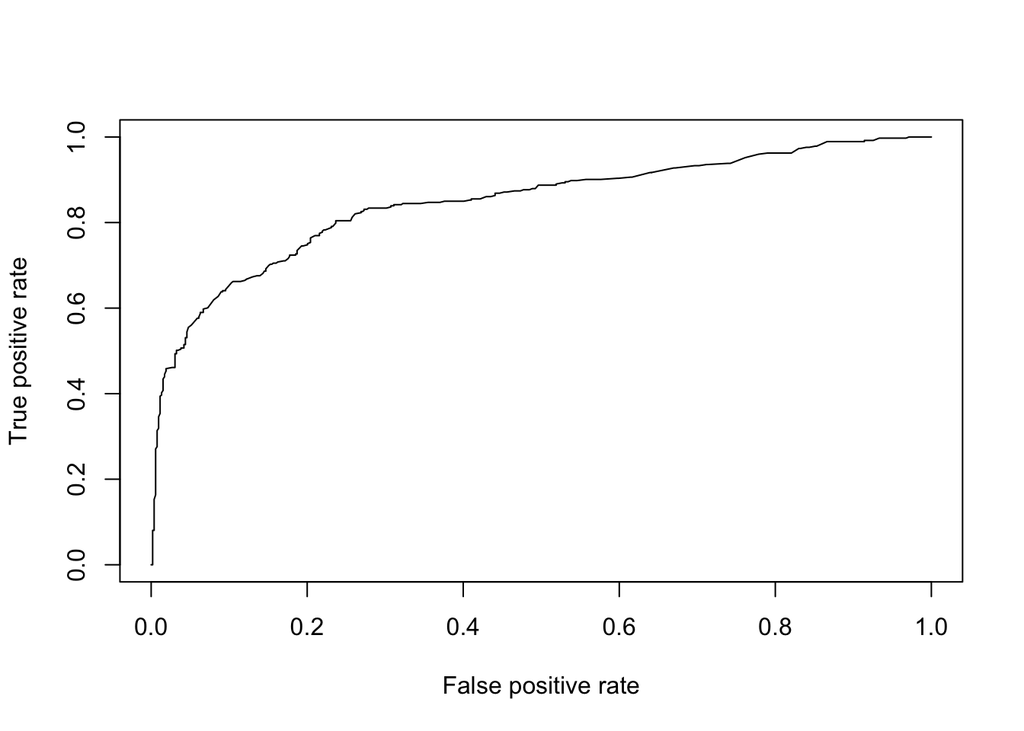

```r
plot(perf)
```

AUC 값을 구합니다.

```r
perf = performance(pred, "auc")
str(perf)
```

```
Formal class 'performance' [package "ROCR"] with 6 slots
  ..@ x.name      : chr "None"
  ..@ y.name      : chr "Area under the ROC curve"
  ..@ alpha.name  : chr "none"
  ..@ x.values    : list()
  ..@ y.values    :List of 1
  .. ..$ : num 0.846
  ..@ alpha.values: list()
```

```r
perf@y.values[[1]]
```

```
[1] 0.8461643
```